# STA 601/360 Homework 2

Yifei Wang

12 September, 2019

## Exec 1. Hoff 3.1 Sample survey: Suppose we are going to sample 100 individuals from a county (of size much larger than 100) and ask each sampled person whether they support policy Z or not. Let $Y_i = 1$ if person $i$ in the sample supports the policy, and $Y_i = 0$ otherwise.

### a) Assume $Y_1$, …, $Y_{100}$ are, conditional on $\theta$, i.i.d. binary random variables with expectation $\theta$. Write down the joint distribution of $Pr(Y_1 = y_1, . . . , Y_{100} = y_{100} \mid \theta)$ in a compact form. Also write down the form of $Pr(\sum Y_i = y \mid \theta)$.

$$P(Y_1 = y_1, . . . , Y_{100} = y_{100} \mid \theta) = \theta^{\sum y_i} (1 - \theta)^{(100-\sum y_i)}$$

$$P(\sum Y_i = y \mid \theta) = {100 \choose y} \theta^{\sum y_i} (1 - \theta)^{(100-\sum y_i)}$$

### (b) For the moment, suppose you believed that $\theta \in \{0.0, 0.1, . . . , 0.9, 1.0\}$. Given that the results of the survey were $\sum_{i=1}^{100} Y_i = 57$, compute $\sum Y_i = 57 \mid \theta$ for each of these 11 values of $\theta$ and plot these probabilities as a function of $\theta$.

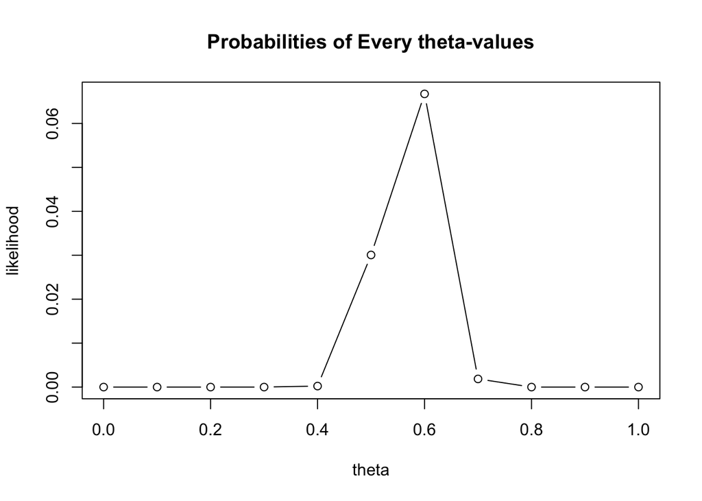

```r
N = 100
y_sum = 57
theta = seq(0, 1, 0.1)
likelihood = choose(N, y_sum) * theta^y_sum * (1 - theta)^(N-y_sum)

plot(theta, likelihood, 'b', main = "Probabilities of Every theta-values")
```

### (c) Now suppose you originally had no prior information to believe one of these $\theta$-values over another, and so $Pr(\theta = 0.0) = Pr(\theta = 0.1) = · · · = Pr(\theta = 0.9) = Pr(\theta = 1.0)$. Use Bayes’ rule to compute $p(\theta \mid \sum_{i=1}^n Y_i = 57)$ for each $\theta$-value. Make a plot of this posterior distribution as a function of $\theta$.

$$Pr(\theta = 0.0) = Pr(\theta = 0.1) = \ldots = Pr(\theta = 0.9) = Pr(\theta = 1.0) = \frac1{11}$$

$$p(\theta \mid \sum_{i=1}^n Y_i = 57) = \frac{p(\sum_{i=1}^n Y_i = 57 \mid \theta) p(\theta)}{p(\sum_{i=1}^n Y_i = 57)} \propto p(\sum_{i=1}^n Y_i = 57 \mid \theta)$$

We need the posterior distribution to be integrated to 1. So we have,

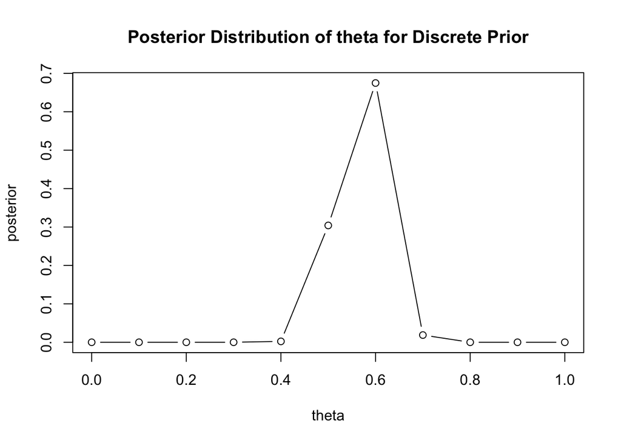

```r
posterior = likelihood / sum(likelihood)

plot(theta, posterior, 'b', main = "Posterior Distribution of theta for Discrete Prior")
```

### (d) Now suppose you allow $\theta$ to be any value in the interval $[0, 1]$. Using the uniform prior density for $\theta$, so that $p(\theta) = 1$, plot $p(\theta) \times Pr(\sum_{i=1}^n Y_i = 57 \mid \theta)$ as a function of $\theta$

$$p(\theta) \times p(\sum_{i=1}^n Y_i = 57 \mid \theta) = {100 \choose 57} \theta^{57} (1-\theta)^{43}$$

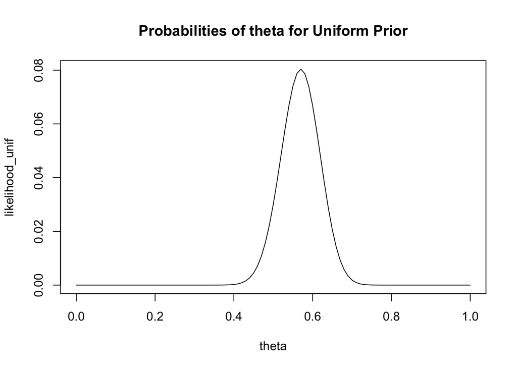

```r
theta = seq(0, 1, 0.01)
y_sum = 57
N = 100
likelihood_unif = choose(N, y_sum) * theta^y_sum * (1 - theta)^(N-y_sum)

plot(theta, likelihood_unif, 'l', main = "Probabilities of theta for Uniform Prior")
```

### (e) As discussed in this chapter, the posterior distribution of $\theta$ is $Beta(1 + 57, 1 + 100 - 57)$. Plot the posterior density as a function of $\theta$. Discuss the relationships among all of the plots you have made for this exercise.

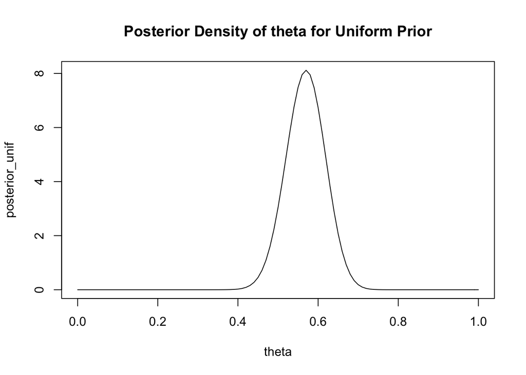

```r
theta = seq(0, 1, 0.01)
y_sum = 57
N = 100
a = 1
b = 1
posterior_unif = beta(a+y_sum, b+N-y_sum)^(-1) * theta^y_sum * (1 - theta)^(N-y_sum)

plot(theta, posterior_unif, 'l', main = "Posterior Density of theta for Uniform Prior")
```

We have 2 different priors, discrete uniform and continuous uniform. For the discrete one, the posterior probabiliy mass function has the identical shape with the sample method $P(\sum Y_i \mid \theta)$ (likelihood). For the continuous one, the posterior probability density function has the identical shape with the product of sample method and priors (because $p(\theta) \equiv 1$). Also, the shape of posterior probability function of the continuous one is similar to the discrete one, because both priors are uniformly and equivantly spaned from 0 to 1.

## Exec 2. Hoff 3.2 Sensitivity analysis: It is sometimes useful to express the parameters $a$ and $b$ in a beta distribution in terms of $\theta_0 = \frac{a}{a + b} and n_0 = a + b$, so that $a = \theta_0 n_0$ and $b = (1 - \theta_0) n_0$. Reconsidering the sample survey data in Exercise 3.1, for each combination of $\theta_0 \in \{0.1, 0.2, . . . , 0.9\}$ and $n_0 \in \{1, 2, 8, 16, 32\}$ find the corresponding $a$, $b$ values and compute $Pr(\theta > 0.5 \mid \sum Y_i = 57)$ using a $Beta(a, b)$ prior distribution for $\theta$. Display the results with a contour plot, and discuss how the plot could be used to explain to someone whether or not they should believe that $\theta > 0.5$, based on the data that $\sum_{i=1}^n Y_i = 57$.

| (a, b) | 0.1 | 0.2 | 0.3 | 0.4 | 0.5 | 0.6 | 0.7 | 0.8 | 0.9 |
| --- | --- | --- | --- | --- | --- | --- | --- | --- | --- |
| 1 | (0.1, 0.9) | (0.2, 0.8) | (0.3, 0.7) | (0.4, 0.6) | (0.5, 0.5) | (0.6, 0.4) | (0.7, 0.3) | (0.8, 0.2) | (0.9, 0.1) |
| 2 | (0.2, 1.8) | (0.4, 1.6) | (0.6, 1.4) | (0.8, 1.2) | (1.0, 1.0) | (1.2, 0.8) | (1.4, 0.6) | (1.6, 0.4) | (1.8, 0.2) |
| 8 | (0.8, 7.2) | (1.6, 6.4) | (2.4, 5.6) | (3.2, 4.8) | (4.0, 4.0) | (4.8, 3.2) | (5.6, 2.4) | (6.4, 1.6) | (7.2, 0.8) |
| 16 | (1.6, 14.4) | (3.2, 12.8) | (4.8, 11.2) | (6.4, 9.6) | (8.0, 8.0) | (9.6, 6.4) | (11.2, 4.8) | (12.8, 3.2) | (14.4, 1.6) |
| 32 | (3.2, 28.8) | (6.4, 25.6) | (9.6, 22.4) | (12.8, 19.2) | (16.0, 16.0) | (19.2, 12.8) | (22.4, 9.6) | (25.6, 6.4) | (28.8, 3.2) |

$$\begin{aligned}
P(\theta \mid \sum Y_i = 57)
&= \frac{P(\sum Y_i = 57 \mid \theta) \; P(\theta)}{P(\sum Y_i = 57)} \\
&= \frac{{100 \choose 57} \theta^{57} (1-\theta)^{43} Beta(a, b)}{P(\sum Y_i = 57)} \\
&= Beta(a+y, b+n-y) \\
&= Beta(a + 57, b + 43)
\end{aligned}$$

$$\begin{aligned}
Pr(\theta > 0.5 \mid \sum Y_i = 57) = Pr(Beta(a + 57, b + 43) > 0.5)
\end{aligned}$$

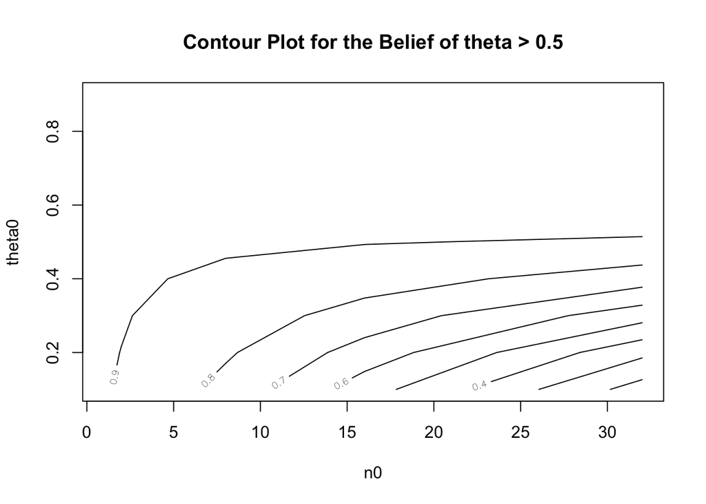

```r
theta0 = seq(0.1, 0.9, 0.1)
n0 = c(1, 2, 8, 16, 32)
a = outer(n0, theta0)
b = outer(n0, 1-theta0)

Pr = 1 - pbeta(0.5, a+y_sum, b+N-y_sum)
contour(x=n0, y=theta0, z=Pr, xlab="n0", ylab="theta0",
        main="Contour Plot for the Belief of theta > 0.5")
```

Given the fact that $\sum_{i=1}^{100} Y_i = 57$, this plot could be interpretated as how the prior knowledge influence on the posterior belief of whether $\theta$ is greater than 0.5. $n_0$ could be interpretated as the number of prior sample size and $\theta_0$ could be treated as the prior $\theta$. The value of $\theta_0$ will affect the value of $\theta$, by dragging the likelihood function towards the prior. Given $n = 100$, this “dragging” effect is determined by the values of $n_0$ and the differences between $\theta$ and $\theta_0$. The greater the differences, or the greater the $n_0$, the greater the effect People should probably believe that $\theta > 0$ when the combination of $theta_0$ and $n_0$ falls into the upper part of the 0.5 contour line.